# If not me, then who? Responsibility and replacement

Sarah A. Wu and Tobias Gerstenberg

August 24, 2023

# 1 Setup

# 2 Helper functions

## 2.1 Demographics

```r
fem = c('female', 'feminine', 'f', 'women')
masc = c('male', 'man', 'm', 'trans man', 'masculine', 'masculino')
nonb = c('non-binary')

white = c('caucasian', 'caucasian/white', 'caucasic', 'caucasoid', 'european', 'greek - white',
          'italian', 'polish', 'middle eastern', 'egyptian', 'mediterranean white', 'mena',
          'south european caucasian', 'white', 'white british', 'white/caucasian', 'whitr')
black = c('black', 'black/african american', 'north african')
asian = c('asian', 'indian')
ind_nat = c('american indian/alaska native')
multi = c('mixed', 'asian and white', 'asian/white', 'black/aa + asian', 'multi-racial',
          'white + asian')
other = c('brown', 'latinx/hispanic/caribbean', 'prefer not to say')
```

```r
print_demographics = function(data) {
  data = data %>%
    mutate(gender = tolower(gender),
           race = tolower(race),
           gender = case_when(gender %in% fem ~ 'Female',
                              gender %in% masc ~ 'Male',
                              gender %in% nonb ~ 'Non-binary',
                              TRUE ~ NA_character_),
           race = case_when(race %in% white ~ 'White',
                            race %in% black ~ 'Black',
                            race %in% asian ~ 'Asian',
                            race %in% ind_nat ~ 'American Indian/Alaska Native',
                            race %in% multi ~ 'Multiracial',
                            race %in% other ~ 'Undisclosed/other',
                            TRUE ~ NA_character_))
  # gender
  data %>%
    group_by(gender) %>%
    summarise(n = n()) %>%
    print()

  # age
  print('age:')
  mean(data$age, na.rm = T) %>% print()
  sd(data$age, na.rm = T) %>% print()

  # race
  data %>%
    group_by(race) %>%
    summarise(n = n()) %>%
    print()

  # ethnicity
  data %>%
    group_by(ethnicity) %>%
    summarise(n = n()) %>%
    print()

  # time taken
  print('time taken (min):')
  print(mean(data$time, na.rm = T)/60/1000)
  print(sd(data$time, na.rm = T)/60/1000)
}
```

## 2.2 Parameter search

### 2.2.1 Uniform probability

```r
update_search_one = function(exp, condition, p) {
  type = ifelse(condition == 'agent', 'craft', 'color')

  data = get(paste0('data.exp', exp, '.', condition)) %>%
    mutate(prob = 1 - (1-p)^num)
  info = get(paste0('info.exp', exp, '.', condition))
  model = lmer(resp ~ 1 + prob + (1 | id),
               data = data)
  data_means = data %>%
    mutate(pred = model %>%
            predict(newdata = data,
                    re.form = NA)) %>%
    group_by_at(c('trial', type, 'pred')) %>%
    summarise(resp = mean(resp),
              pred = mean(pred)) %>%
    merge(info %>%
            select(trial, type),
          by = c('trial', type))
  rmse = rmse(data_means$resp, data_means$pred)
  data_rmse = get(paste0('rmse.exp', exp, '.', condition, '_uniform')) %>%
    rbind(c(p, rmse))

  return(data_rmse)
}
```

```r
plot_search_one = function(exp, condition) {
  data_rmse =  get(paste0('rmse.exp', exp, '.', condition, '_uniform'))

  g = ggplot(data_rmse,
             aes(x = p,
                 y = rmse)) +
    geom_point() +
    # best parametrization
    geom_point(data = data_rmse %>%
                 filter(rmse == min(rmse)),
               color = 'red') +
    ggtitle(paste(condition, 'condition')) +
    theme(text = element_text(size = 12),
          axis.ticks.x = element_blank()) +
    scale_x_continuous(name = 'p',
                       limits = c(0, 1),
                       breaks = seq(0, 1, by = 0.2)) +
    scale_y_continuous(name = 'RMSE',
                       limits = c(0, 5.5),
                       breaks = seq(0, 5))
  return(g)
}
```

### 2.2.2 Varying probabilities

```r
update_search_two = function(exp, condition, p_low, p_high) {
  type = ifelse(condition == 'agent', 'craft', 'color')

  data = get(paste0('data.exp', exp, '.', condition)) %>%
    mutate(prob = 1 - (1-p_low)^low * (1-p_high)^high)
  info = get(paste0('info.exp', exp, '.', condition))
  model = lmer(resp ~ 1 + prob + (1 | id),
               data = data)
  data_means = data %>%
    mutate(pred = model %>%
            predict(newdata = data,
                    re.form = NA)) %>%
    group_by_at(c('trial', type, 'pred')) %>%
    summarise(resp = mean(resp),
              pred = mean(pred)) %>%
    merge(info %>%
            select(trial, type),
          by = c('trial', type))
  rmse = rmse(data_means$resp, data_means$pred)
  data_rmse = get(paste0('rmse.exp', exp, '.', condition, '_full')) %>%
    rbind(c(p_low, p_high, rmse))

  return(data_rmse)
}
```

```r
plot_search_two = function(exp, condition) {
  data_rmse =  get(paste0('rmse.exp', exp, '.', condition, '_full')) %>%
    mutate(p_low = as.factor(p_low),
           p_high = as.factor(p_high))

  g = ggplot(data_rmse,
             aes(x = p_low,
                 y = p_high,
                 fill = rmse)) +
    geom_tile(color = 'black') +
    coord_fixed() + # square tiles
    # best parametrization
    geom_point(data = data_rmse %>%
                 filter(rmse == min(rmse)),
               color = 'red',
               size = 2) +
    scale_fill_gradient(low = "gray20", high = "white") +
    guides(fill = guide_colourbar(barwidth = 0.5,
                                  barheight = 5,
                                  title = 'RMSE')) +
    ggtitle(paste(condition, 'condition')) +
    theme(text = element_text(size = 12),
          legend.position = c(0.9, 0.3),
          axis.ticks.x = element_blank()) +
    scale_x_discrete(name = 'low availability p',
                     breaks = seq(0, 1, by = 0.2)) +
    scale_y_discrete(name = 'high availability p',
                     breaks = seq(0, 1, by = 0.2))
  return(g)
}
```

## 2.3 Make scatter plot

```r
make_scatter = function(data_means, model_name, xlabel, breaks) {
  col_name = paste('pred_', model_name, sep = '')

  if (model_name == 'baseline') {
    r = 'N/A'
  } else {
    r = cor(data_means$resp_mean, data_means[[col_name]]) %>%
      round(2)
  }

  rmse = rmse(data_means$resp_mean, data_means[[col_name]])

  g = ggplot(data = data_means,
             aes(x = get(col_name),
                 y = resp_mean)) +
    geom_abline(intercept = 0, slope = 1, linetype = 2) +
    geom_linerange(size = 0.5,
                   mapping = aes(ymin = resp_low,
                                 ymax = resp_high),
                   color = "lightgray") +
    geom_point(size = 2, shape = 21, stroke = 0.5,
               fill = 'gray', color = 'black') +
    theme(text = element_text(size = 12),
          legend.position = "none") +
    annotate('text',
             label = sprintf('r = %s\nRMSE = %.2f', r, rmse),
             hjust = 0,   # left align
             x = breaks[1], y = breaks[length(breaks)] - 2) +
    scale_x_continuous(name = xlabel,
                       breaks = breaks,
                       limits = c(breaks[1], breaks[length(breaks)])) +
    scale_y_continuous(name = 'responsibility judgment',
                       breaks = breaks,
                       limits = c(breaks[1], breaks[length(breaks)])) +
    coord_fixed(ratio = 1)

  return(g)
}
```

```r
agent_icon = readPNG(paste0(figures_dir, 'icons/agent.png')) %>%
  rasterGrob(interpolate = T)
object_icon = readPNG(paste0(figures_dir, 'icons/object.png')) %>%
  rasterGrob(interpolate = T)
```

# 3 Experiment 1

## 3.1 Data

### 3.1.1 Agent condition

#### 3.1.1.1 Trial info

```r
info.exp1.agent = read_csv(paste0(data_dir, 'experiment1_agent/trial_info.csv'),
                           show_col_types = F) %>%
  pivot_longer(cols = !trial,
               names_to = c('.value', 'craft'),
               names_pattern = '(.+)_(.)')
```

#### 3.1.1.2 Response data

```r
data.exp1.agent = read_csv(paste0(data_dir, 'experiment1_agent/trials.csv'),
                           show_col_types = F) %>%
  select(-error, -proliferate.condition) %>%
  rename(id = workerid,
         b = resp_b, c = resp_c, t = resp_t) %>%
  # filter by exclusion trial X1
  pivot_wider(names_from = trial, values_from = c(c, b, t)) %>%
  rowwise(id) %>%
  filter(max(c_X1, b_X1, t_X1) - min(c_X1, b_X1, t_X1) < 30) %>%
  # pivot back to long form
  pivot_longer(cols = !id,
               names_to = 'trial',
               values_to = 'resp') %>%
  separate(col = trial,
           into = c('craft', 'trial'),
           sep = '_') %>%
  # ignore exclusion trial and practice trials
  filter(!(trial %in% c("X1", 1, 2))) %>%
  # merge with trial info
  merge(info.exp1.agent,
        by = c('trial', 'craft')) %>%
  # factor variables for plotting
  mutate(id = factor(id),
         plot_id = as.factor(as.integer(id)),
         craft = factor(craft))
```

Number of participants:

```r
length(unique(data.exp1.agent$id))
```

```
## [1] 50
```

#### 3.1.1.3 Participant data

Participants were asked: “What factors influenced how you decided to respond? Do you have any questions or comments regarding the experiment?”

```r
participants.exp1.agent = read_csv(paste0(data_dir, 'experiment1_agent/participants.csv'),
                                   show_col_types = F) %>%
  select(-error, -proliferate.condition) %>%
  rename(id = workerid) %>%
  filter(id %in% data.exp1.agent$id) %>%
  mutate(id = factor(id)) %>%
  left_join(data.exp1.agent %>%
              distinct(id, plot_id),
            by = 'id')

participants.exp1.agent %>%
  select(plot_id, feedback) %>%
  datatable()
```

|  | plot_id | feedback |
| --- | --- | --- |
| 1 | 3 | tHE FACTOR THAT EVERY CRAFTPERSON WAS INDISPENSABLE AND ESSENTIAL IN ORDER TO BUILD THE SHIPMENT, I CHOOSE THAT EVERYONE WAS VERY RESPONSIBLE |
| 2 | 8 | The number of available villagers determines the level of responsibility of the success of the ship build |
| 3 | 12 | Amount of people. No, but good job! Have a great day! |
| 4 | 33 | How many craftsmen of that kind were available in the village |
| 5 | 20 | I tend to think that if there are a lot of people doing the same job, maybe they are more invested in doing a good job (from the perspective that there isn't enough work for everybody). Therefore, if … |
| 6 | 30 | all workeres are equaly important |
| 7 | 26 | I think who has less choice that person is more responsible. |
| 8 | 6 | Independently of how many carpenters, blacksmiths or tailors existed in each town, each one of them that was building the ship was equally important. Because without one of them they wouldn't be able … |
| 9 | 24 | All the craftspeople are equally important, as they all give the same contribute to the ship built |
| 10 | 7 |  |

[output cut: 40 more lines]

### 3.1.2 Object condition

#### 3.1.2.1 Trial info

```r
info.exp1.object = read_csv(paste0(data_dir, 'experiment1_object/trial_info.csv'),
                            show_col_types = F) %>%
  pivot_longer(cols = !trial,
               names_to = c('.value', 'color'),
               names_pattern = '(.+)_(.)')
```

#### 3.1.2.2 Response data

```r
data.exp1.object = read_csv(paste0(data_dir, 'experiment1_object/trials.csv'),
                            show_col_types = F) %>%
  select(-error, -proliferate.condition) %>%
  rename(id = workerid,
         y = resp_y, g = resp_g, b = resp_b) %>%
  # filter by exclusion trial X1
  pivot_wider(names_from = trial, values_from = c(y, g, b)) %>%
  rowwise(id) %>%
  filter(max(y_X1, g_X1, b_X1) - min(y_X1, g_X1, b_X1) < 30) %>%
  # pivot back to long form
  pivot_longer(cols = !id,
               names_to = 'trial',
               values_to = 'resp') %>%
  separate(col = trial,
           into = c('color', 'trial'),
           sep = '_') %>%
  # ignore exclusion trial and practice trials
  filter(!(trial %in% c("X1", 1, 2))) %>%
  # merge with trial info
  merge(info.exp1.object,
        by = c('trial', 'color')) %>%
  # factor variables for plotting
  mutate(id = factor(id),
         plot_id = as.factor(as.integer(id)),
         color = factor(color))
```

Number of participants:

```r
length(unique(data.exp1.object$id))
```

```
## [1] 50
```

#### 3.1.2.3 Participant data

Participants were asked: “What factors influenced how you decided to respond? Do you have any questions or comments regarding the experiment?”

```r
participants.exp1.object = read_csv(paste0(data_dir, 'experiment1_object/participants.csv'),
                                    show_col_types = F) %>%
  select(-error, -proliferate.condition) %>%
  rename(id = workerid) %>%
  filter(id %in% data.exp1.object$id) %>%
  mutate(id = factor(id)) %>%
  left_join(data.exp1.object %>%
              distinct(id, plot_id),
            by = 'id')

participants.exp1.object %>%
  select(plot_id, feedback) %>%
  datatable()
```

|  | plot_id | feedback |
| --- | --- | --- |
| 1 | 46 | The number of gears in every village, in the firsts villages i thought what when less gears were,less imporntace they had, but at the end of the excersice i realice that actually i was wrong, so i cha… |
| 2 | 38 | how many wheels were available |
| 3 | 25 | Primarily the quantity for each color of gear. |
| 4 | 27 | The fact that there was one workink¿g gear in each group, all the types of gears were really imporant for the machine to be working |
| 5 | 10 | the number of replacement gears |
| 6 | 44 | The ammount of gear. |
| 7 | 43 | The amount of these gears decided what i choosed. |
| 8 | 35 | The more gears of the same color village had, the less responsible the one of the same color was, because in case one fails there's another to replace it. |
| 9 | 7 | The amount of gears in relation to the gears chosen was the only influence |
| 10 | 30 | If the machine needs 1 of each it doesnt matter how many of each you've got. |

[output cut: 40 more lines]

### 3.1.3 Demographics

```r
participants.exp1.agent %>%
  rbind(participants.exp1.object) %>%
  print_demographics()
```

```
## # A tibble: 4 × 2
##   gender         n
##   <chr>      <int>
## 1 Female        34
## 2 Male          63
## 3 Non-binary     1
## 4 <NA>           2
## [1] "age:"
## [1] 24.84
## [1] 5.814854
## # A tibble: 5 × 2
##   race            n
##   <chr>       <int>
## 1 Asian           7
## 2 Black           7
## 3 Multiracial     3
## 4 White          64
## 5 <NA>           19
## # A tibble: 3 × 2
##   ethnicity        n
##   <chr>        <int>
## 1 Hispanic        29
## 2 Non-Hispanic    70
## 3 <NA>             1
## [1] "time taken (min):"
## [1] 9.846081
## [1] 5.648796
```

## 3.2 Models

### 3.2.1 Agent condition

#### 3.2.1.1 Parameter search

```r
rmse.exp1.agent_uniform = data.frame()
for (p in seq(0, 1, by = 0.05)) {
  rmse.exp1.agent_uniform = update_search_one(1, 'agent', p)
}
colnames(rmse.exp1.agent_uniform) = c('p', 'rmse')

# get optimal values
p.exp1.agent = rmse.exp1.agent_uniform[which.min(rmse.exp1.agent_uniform$rmse),]$p

# create plot
plot_rmse.exp1.agent = plot_search_one(1, 'agent')

# update response data
data.exp1.agent = data.exp1.agent %>%
  mutate(prob = 1 - (1 - p.exp1.agent)^num)
```

#### 3.2.1.2 Overall models

Fitting baseline model:

```r
fit.exp1.agent_baseline = brm(
  formula = resp ~ 1 + (1 | id),
  data = data.exp1.agent,
  iter = 8000,
  seed = 1,
  file = "cache/fit.exp1.agent_baseline")
```

Fitting counterfactual replacement model (CRM):

```r
fit.exp1.agent_crm = brm(
  formula = resp ~ 1 + prob +  (1 + prob | id),
  data = data.exp1.agent,
  iter = 8000,
  seed = 1,
  file = "cache/fit.exp1.agent_crm")
```

Comparing models with leave-one-out cross-validation:

```r
fit.exp1.agent_baseline = add_criterion(
  fit.exp1.agent_baseline,
  criterion = "loo",
  reloo = T,
  file = "cache/fit.exp1.agent_baseline")

fit.exp1.agent_crm = add_criterion(
  fit.exp1.agent_crm,
  criterion = "loo",
  reloo = T,
  file = "cache/fit.exp1.agent_crm")

loo_compare(fit.exp1.agent_baseline,
            fit.exp1.agent_crm)
```

```
##                         elpd_diff se_diff
## fit.exp1.agent_crm          0.0       0.0
## fit.exp1.agent_baseline -1591.1      74.2
```

#### 3.2.1.3 Individual models

```r
prior = c(prior(normal(0, 20), class = 'b', ub = 0))

# initialize the models
fit.exp1.agent_baseline_individual = brm(
  formula = resp ~ 1,
  data = data.exp1.agent %>%
    filter(plot_id == 1),
  seed = 1,
  file = "cache/fit.exp1.agent_baseline_individual")

fit.exp1.agent_crm_individual = brm(
  formula = resp ~ 1 + prob,
  data = data.exp1.agent %>%
    filter(plot_id == 1),
  prior = prior,
  seed = 1,
  file = "cache/fit.exp1.agent_crm_individual")

# update model fits for each participant
data.exp1.agent_model_fits = data.exp1.agent %>%
  group_by(plot_id) %>%
  nest() %>%
  ungroup() %>%
  mutate(fit_baseline = map(.x = data,
                            .f = ~ update(fit.exp1.agent_baseline_individual,
                                          newdata = .x,
                                          seed = 1)),
         fit_crm = map(.x = data,
                       .f = ~ update(fit.exp1.agent_crm_individual,
                                     newdata = .x,
                                     seed = 1))) %>%
  mutate(fit_baseline = map(.x = fit_baseline,
                            .f = ~ add_criterion(.x, criterion = "loo")),
         fit_crm = map(.x = fit_crm,
                       .f = ~ add_criterion(.x, criterion = "loo")),
         model_comparison = pmap(.l = list(baseline = fit_baseline,
                                           crm = fit_crm),
                                 .f = ~ loo_compare(..1, ..2)),
         best_model = map_chr(.x = model_comparison,
                              .f = ~ rownames(.) %>%
                                .[1]),
         best_model = factor(best_model,
                             levels = c("..1", "..2"),
                             labels = c("baseline",
                                        "crm")))

save(list = c("data.exp1.agent_model_fits"),
     file = paste0(data_dir, 'experiment1_agent/model-fits.RData'))
```

```r
load(file = paste0(data_dir, 'experiment1_agent/model-fits.RData'))

data.exp1.agent_model_fits %>%
  count(best_model) %>%
  arrange(desc(n))
```

```
## # A tibble: 2 × 2
##   best_model     n
##   <fct>      <int>
## 1 crm           32
## 2 baseline      18
```

### 3.2.2 Object condition

#### 3.2.2.1 Parameter search

```r
rmse.exp1.object_uniform = data.frame()
for (p in seq(0, 1, by = 0.05)) {
  rmse.exp1.object_uniform = update_search_one(1, 'object', p)
}
colnames(rmse.exp1.object_uniform) = c('p', 'rmse')

# get optimal values
p.exp1.object = rmse.exp1.object_uniform[which.min(rmse.exp1.object_uniform$rmse),]$p

# create plot
plot_rmse.exp1.object = plot_search_one(1, 'object')

# update response data
data.exp1.object = data.exp1.object %>%
  mutate(prob = 1 - (1 - p.exp1.object)^num)
```

#### 3.2.2.2 Overall models

Fitting baseline model:

```r
fit.exp1.object_baseline = brm(
  formula = resp ~ 1 + (1 | id),
  data = data.exp1.object,
  iter = 8000,
  seed = 1,
  file = "cache/fit.exp1.object_baseline")
```

Fitting counterfactual replacement model (CRM):

```r
fit.exp1.object_crm = brm(
  formula = resp ~ 1 + prob +  (1 + prob | id),
  data = data.exp1.object,
  iter = 8000,
  seed = 1,
  file = "cache/fit.exp1.object_crm")
```

Comparing models with leave-one-out cross-validation:

```r
fit.exp1.object_baseline = add_criterion(
  fit.exp1.object_baseline,
  criterion = "loo",
  reloo = T,
  file = "cache/fit.exp1.object_baseline")

fit.exp1.object_crm = add_criterion(
  fit.exp1.object_crm,
  criterion = "loo",
  reloo = T,
  file = "cache/fit.exp1.object_crm")

loo_compare(fit.exp1.object_baseline,
            fit.exp1.object_crm)
```

```
##                          elpd_diff se_diff
## fit.exp1.object_crm          0.0       0.0
## fit.exp1.object_baseline -1778.2      80.2
```

#### 3.2.2.3 Individual models

```r
prior = c(prior(normal(0, 20), class = 'b', ub = 0))

# initialize the models
fit.exp1.object_baseline_individual = brm(
  formula = resp ~ 1,
  data = data.exp1.object %>%
    filter(plot_id == 1),
  seed = 1,
  file = "cache/fit.exp1.object_baseline_individual")

fit.exp1.object_crm_individual = brm(
  formula = resp ~ 1 + prob,
  data = data.exp1.object %>%
    filter(plot_id == 1),
  prior = prior,
  seed = 1,
  file = "cache/fit.exp1.object_crm_individual")

# update model fits for each participant
data.exp1.object_model_fits = data.exp1.object %>%
  group_by(plot_id) %>%
  nest() %>%
  ungroup() %>%
  mutate(fit_baseline = map(.x = data,
                            .f = ~ update(fit.exp1.object_baseline_individual,
                                          newdata = .x,
                                          seed = 1)),
         fit_crm = map(.x = data,
                       .f = ~ update(fit.exp1.object_crm_individual,
                                     newdata = .x,
                                     seed = 1))) %>%
  mutate(fit_baseline = map(.x = fit_baseline,
                            .f = ~ add_criterion(.x, criterion = "loo")),
         fit_crm = map(.x = fit_crm,
                       .f = ~ add_criterion(.x, criterion = "loo")),
         model_comparison = pmap(.l = list(baseline = fit_baseline,
                                           crm = fit_crm),
                                 .f = ~ loo_compare(..1, ..2)),
         best_model = map_chr(.x = model_comparison,
                              .f = ~ rownames(.) %>%
                                .[1]),
         best_model = factor(best_model,
                             levels = c("..1", "..2"),
                             labels = c("baseline",
                                        "crm")))

save(list = c("data.exp1.object_model_fits"),
     file = paste0(data_dir, 'experiment1_object/model-fits.RData'))
```

```r
load(file = paste0(data_dir, 'experiment1_object/model-fits.RData'))

data.exp1.object_model_fits %>%
  count(best_model) %>%
  arrange(desc(n))
```

```
## # A tibble: 2 × 2
##   best_model     n
##   <fct>      <int>
## 1 crm           37
## 2 baseline      13
```

## 3.3 Plots

### 3.3.1 Parameter search

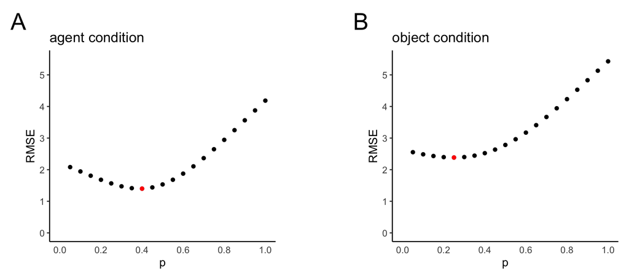

```r
plot_rmse.exp1.agent + plot_spacer() + plot_rmse.exp1.object +
  plot_annotation(tag_levels = 'A') +
  plot_layout(widths = c(4, 1, 4)) &
  theme(plot.tag = element_text(size = 24))
```

```r
# ggsave(paste0(figures_dir, '/experiment1/p_search.pdf'), width = 9, height = 4)
```

### 3.3.2 Setting up data

```r
data.exp1.agent = data.exp1.agent %>%
  cbind(fit.exp1.agent_baseline %>%
          fitted(newdata = data.exp1.agent,
                 re_formula = NA) %>%
          as_tibble() %>%
          mutate(pred_baseline = Estimate) %>%
          select(pred_baseline)) %>%
  cbind(fit.exp1.agent_crm %>%
          fitted(newdata = data.exp1.agent,
                 re_formula = NA) %>%
          as_tibble() %>%
          mutate(pred_crm = Estimate) %>%
          select(pred_crm))

data.exp1.agent_means = data.exp1.agent %>%
  group_by(trial, craft) %>%
  summarise(resp_mean = mean(resp),
            resp_low = smean.cl.boot(resp)[2],
            resp_high = smean.cl.boot(resp)[3]) %>%
  merge(info.exp1.agent, by = c('trial', 'craft')) %>%
  left_join(data.exp1.agent %>%
              distinct(trial, craft, pred_baseline, pred_crm),
            by = c('trial', 'craft'))
```

```r
data.exp1.object = data.exp1.object  %>%
  cbind(fit.exp1.object_baseline %>%
          fitted(newdata = data.exp1.object ,
                 re_formula = NA) %>%
          as_tibble() %>%
          mutate(pred_baseline = Estimate) %>%
          select(pred_baseline)) %>%
  cbind(fit.exp1.object_crm %>%
          fitted(newdata = data.exp1.object ,
                 re_formula = NA) %>%
          as_tibble() %>%
          mutate(pred_crm = Estimate) %>%
          select(pred_crm))

data.exp1.object_means = data.exp1.object  %>%
  group_by(trial, color) %>%
  summarise(resp_mean = mean(resp),
            resp_low = smean.cl.boot(resp)[2],
            resp_high = smean.cl.boot(resp)[3]) %>%
  merge(info.exp1.object, by = c('trial', 'color')) %>%
  left_join(data.exp1.object  %>%
              distinct(trial, color, pred_baseline, pred_crm),
            by = c('trial', 'color'))
```

```r
model_labels.exp1 = c('baseline' = 'Contribution model',
                      'crm' = 'CRM')

model_order.exp1 = c('baseline', 'crm')
```

### 3.3.3 Scatter plots

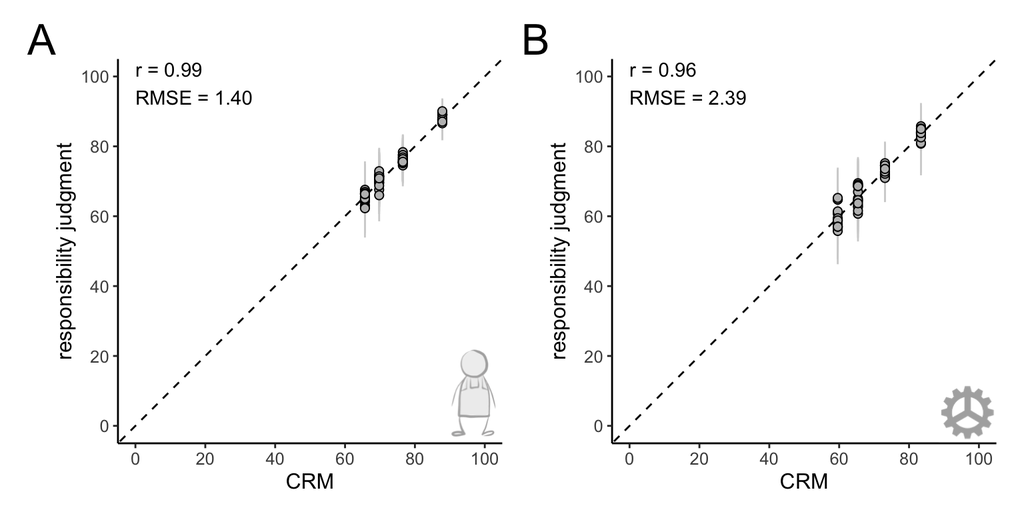

```r
scatter.exp1.agent_crm = make_scatter(
  data.exp1.agent_means, 'crm', 'CRM', seq(0, 100, 20))
scatter.exp1.object_crm = make_scatter(
  data.exp1.object_means, 'crm', 'CRM', seq(0, 100, 20))

scatter.exp1.agent_crm + inset_element(agent_icon, 0.85, 0.01, 1, 0.25) +
  scatter.exp1.object_crm + inset_element(object_icon, 0.85, 0.01, 1, 0.15) +
  plot_layout(ncol = 2) +
  plot_annotation(tag_levels = list(c('A', '', 'B', ''))) &
  theme(plot.title = element_text(hjust = 0.5),
        plot.tag = element_text(size = 24))
```

```r
# ggsave(paste0(figures_dir, 'experiment1/scatter.pdf'), width = 8, height = 4)
```

### 3.3.4 Bar plot

```r
barplot.exp1 = function(data, fill) {
  g = ggplot(data = data,
             mapping = aes(x = num,
                           y = resp)) +
    stat_summary(fun = "mean",
                 geom = "bar",
                 color = 'black',
                 fill = fill,
                 width = 0.8) +
    stat_summary(fun.data = "mean_cl_boot",
                 geom = "linerange",
                 size = 1) +
    stat_summary(mapping = aes(y = pred,
                               fill = model,
                               shape = model,
                               size = model),
                 fun = 'mean',
                 geom = 'point',
                 color = 'black',
                 position = position_dodge(width = 0.5)) +
    theme(text = element_text(size = 16),
          legend.position = 'bottom',
          legend.direction = 'horizontal',
          legend.title = element_blank(),
          #axis.text.x = element_blank(),
          axis.line.x = element_blank(),
          axis.ticks.x = element_blank(),
          strip.background = element_blank(),
          strip.text = element_blank(),
          panel.grid.major.y = element_line()) +
    scale_fill_manual(values = c('baseline' = 'black',
                                 'crm' = 'white'),
                      labels = model_labels.exp1,
                      name = 'model') +
    scale_size_manual(values = c('baseline' = 2.5,
                                 'crm' = 3),
                      labels = model_labels.exp1,
                      name = 'model') +
    scale_shape_manual(values = c('baseline' = 21,  # circle
                                  'crm' = 23), # diamond
                       labels = model_labels.exp1,
                       name = 'model') +
    scale_y_continuous(name = 'responsibility judgment',
                       breaks = seq(0, 100, 20),
                       expand = expansion(mult = 0.01)) +
    xlab('number of replacements') +
    coord_cartesian(clip = 'off', ylim = c(0, 100))

  return(g)
}
```

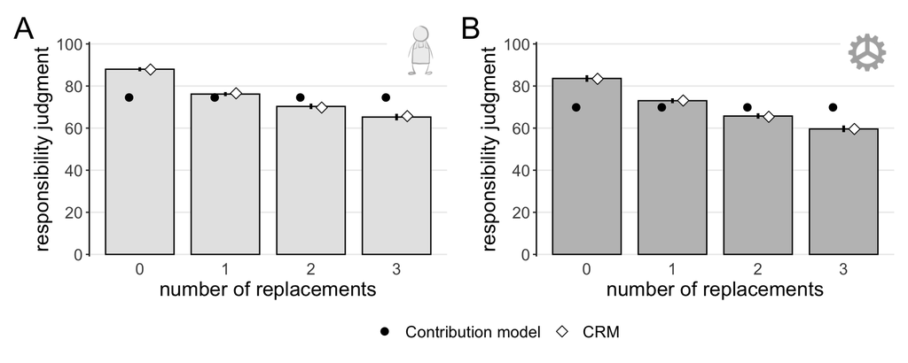

```r
barplot.exp1.agent = barplot.exp1(
  data = data.exp1.agent %>%
    pivot_longer(cols = starts_with('pred'),
                 names_to = 'model',
                 values_to = 'pred') %>%
    mutate(model = factor(sub('^pred_', '', model),
                          levels = model_order.exp1)),
  fill = 'gray90'
)

barplot.exp1.object = barplot.exp1(
  data = data.exp1.object %>%
    pivot_longer(cols = starts_with('pred'),
                 names_to = 'model',
                 values_to = 'pred') %>%
    mutate(model = factor(sub('^pred_', '', model),
                          levels = model_order.exp1)),
  fill = 'gray75'
)

barplot.exp1.agent + inset_element(agent_icon, 0.85, 0.8, 1, 0.95,
                                   align_to = 'full') +
  barplot.exp1.object + inset_element(object_icon, 0.85, 0.9, 1, 1) +
  plot_layout(nrow = 1,
              guides = 'collect') +
  plot_annotation(tag_levels = list(c('A', '', 'B', ''))) &
  theme(plot.tag = element_text(size = 24),
        legend.position = 'bottom')
```

```r
# ggsave(paste0(figures_dir, 'experiment1/bar.pdf'), width = 10, height = 4.5)
```